# Skilled Nursing Facility Strategic Benchmark Report

Client-specific static report from CMS SNF cost-report metrics

# Executive summary

AVENUES HEALTHCARE INC. | CCN 465072 | SALT LAKE CITY, UT | SALT LAKE County

**Overall read: occupancy is broadly in line with similar peers; operating expense per resident day exceeds net patient revenue per resident day; patient service margin is negative; liquidity appears thin based on days cash on hand.**

**Facility:** AVENUES HEALTHCARE INC.  
**CCN:** 465072  
**Location:** SALT LAKE CITY, UT; SALT LAKE County  
**Latest cost-report year:** 2023  
**Peer group:** Same state + same rural/urban + same bed-size band; n = 25.

This report summarizes cost-report-based strategic indicators for the selected skilled nursing facility. It is designed as a first-pass consulting report, not a substitute for audited financial review, facility interviews, staffing data, quality measures, or referral-market analysis.

- Latest occupancy is **70.8%**, compared with a peer median of **71.2%**; the three-year change is up 32.6% from 2020 to 2023.
- Medicare day share is **3.3%** and Medicaid day share is **76.1%**, giving an initial view of post-acute versus long-stay payer mix.
- Net patient revenue per resident day is **$380**, while operating expense per resident day is **$387**.
- Patient service margin is **-1.7%**, compared with a peer median of **2.7%**.
- Contract labor ratio is **9.6%**, compared with a peer median of **7.3%**.

## How to read this report

- **Peer comparisons** use the selected facility’s latest-year peer group: same state, same rural/urban category, and same bed-size band.
- **Trend charts** compare the target facility with the latest-year peer group over time. The shaded band is the peer 25th to 75th percentile range; the dashed line is the peer median; the solid line is the target facility.
- **Cost-report metrics are screening indicators.** They are useful for identifying likely issues and follow-up questions, but they should be validated with staffing, quality, survey, referral, rate, and management information before making operational recommendations.

# Rule-based strategic flags

Risk · Liquidity

Liquidity appears thin

Days cash on hand is below the peer 25th percentile or below 30 days.

# Facility profile

| Field | Value |
| --- | --- |
| Facility | AVENUES HEALTHCARE INC. |
| CCN | 465072 |
| City | SALT LAKE CITY |
| County | SALT LAKE |
| ZIP | 84102 |
| Rural/urban | Urban |
| Ownership/control code | 11 |
| Beds | 80.0 |
| Bed-size band | 50-99 |
| SNF/NF mix | SNF-dominant |
| Latest cost-report year | 2023 |
| Peer group | Same state + same rural/urban + same bed-size band; n = 25 |
| Data quality flags | None listed |

# Latest-year benchmark table

| Metric | Target | Peer median | Peer p25 | Peer p75 | Difference | Percentile |
| --- | --- | --- | --- | --- | --- | --- |
| Utilization |  |  |  |  |  |  |
| Occupancy rate | 70.8% | 71.2% | 62.4% | 83.5% | -0.4% | 48% |
| Payer mix |  |  |  |  |  |  |
| Medicare day share | 3.3% | 5.8% | 3.8% | 13.4% | -2.5% | 24% |
| Medicaid day share | 76.1% | 68.1% | 55.4% | 76.4% | 7.9% | 73% |
| Revenue |  |  |  |  |  |  |
| Net patient revenue per resident day | $380 | $395 | $371 | $426 | -$15 | 36% |
| Cost |  |  |  |  |  |  |
| Operating expense per resident day | $387 | $390 | $360 | $417 | -$4 | 44% |
| Margin |  |  |  |  |  |  |
| Patient service margin | -1.7% | 2.7% | -5.0% | 9.7% | -4.4% | 32% |
| Total margin | -1.7% | 5.2% | -3.2% | 11.1% | -6.9% | 29% |
| Labor |  |  |  |  |  |  |
| Contract labor ratio | 9.6% | 7.3% | 1.4% | 29.1% | 2.4% | 57% |
| Liquidity |  |  |  |  |  |  |
| Days cash on hand | 1.4 | 16.3 | 1.6 | 43.8 | -14.9 | 24% |
| Current ratio | 4.0 | 2.7 | 1.0 | 4.5 | 1.3 | 68% |
| Solvency |  |  |  |  |  |  |
| Debt to assets | 56.4% | 68.9% | 26.6% | 95.7% | -12.5% | 44% |

# Trend analysis

Trend charts show the selected facility against the latest-year peer group where peer comparison is available. Payer mix and revenue-versus-expense charts are target operating views intended to show how the facility’s own business model has changed over time.

## Occupancy

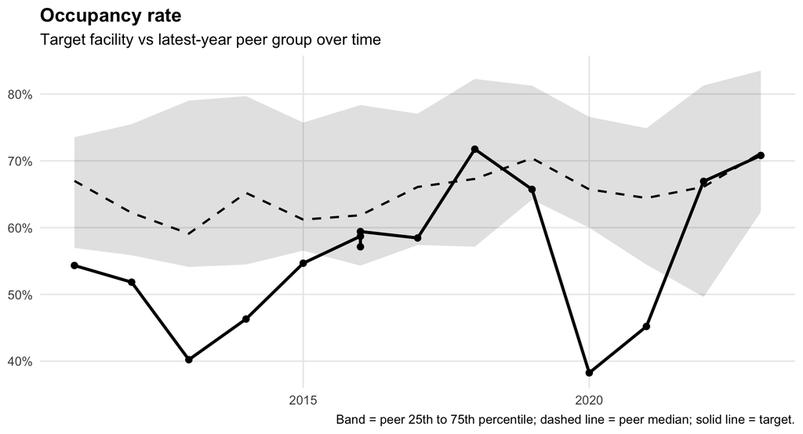

**Interpretation:** Occupancy is the clearest capacity-utilization signal in the cost report. A target line below the peer median suggests census pressure; a target line above peers suggests stronger utilization or a different care model.

## Payer mix

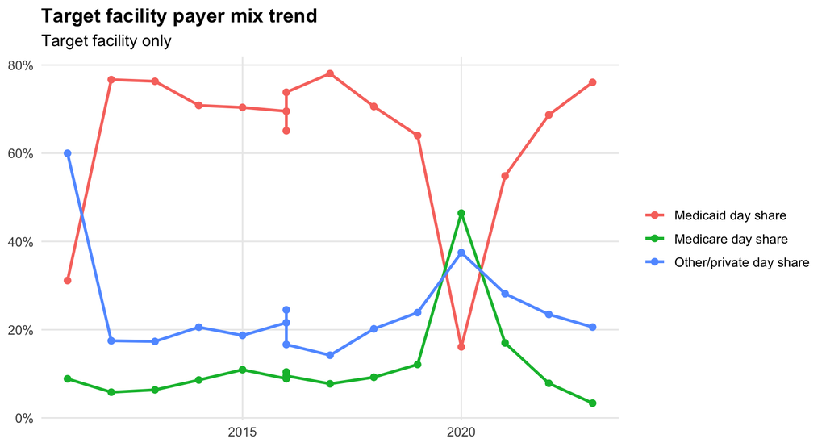

**Interpretation:** Medicare share is a rough proxy for skilled/post-acute orientation, while Medicaid share often reflects long-stay reimbursement exposure. Directional change can matter as much as the latest value.

## Revenue and operating expense per resident day

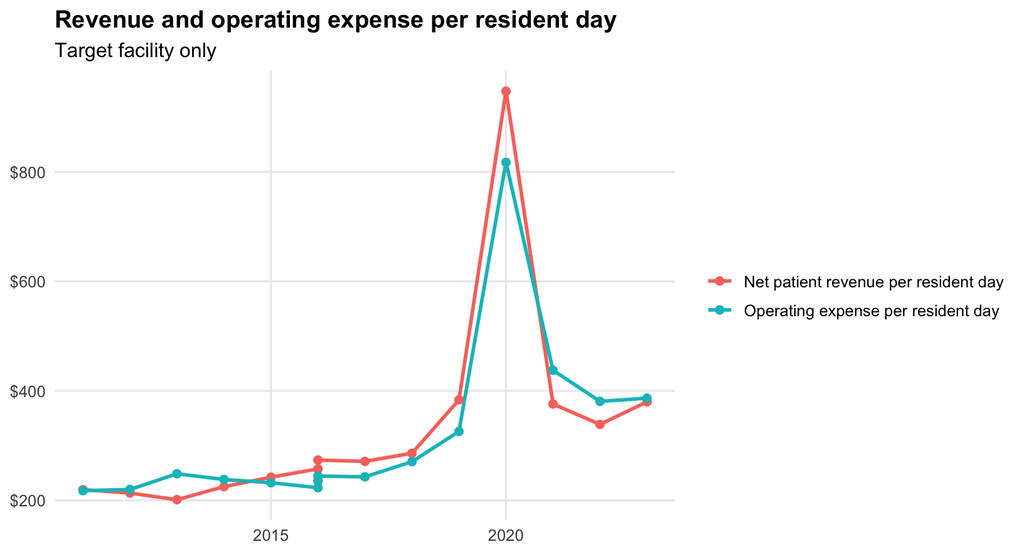

**Interpretation:** If operating expense per day is growing faster than revenue per day, the facility may be facing margin compression even if occupancy is stable.

## Patient service margin

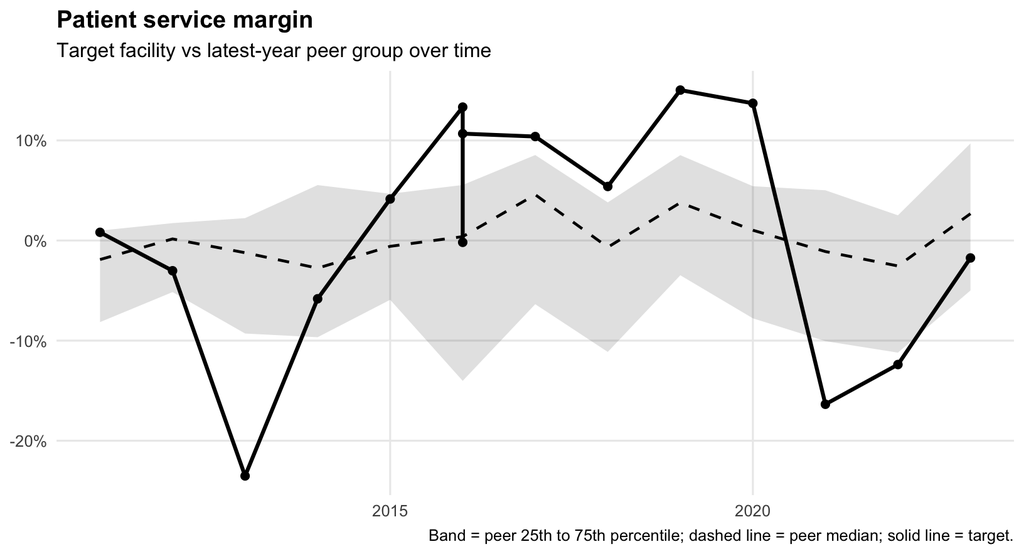

**Interpretation:** Patient service margin shows whether resident-care operations appear financially sustainable based on cost-report fields. A persistent negative margin requires deeper review of payer mix, labor cost, overhead, occupancy, and accounting treatment.

## Contract labor ratio

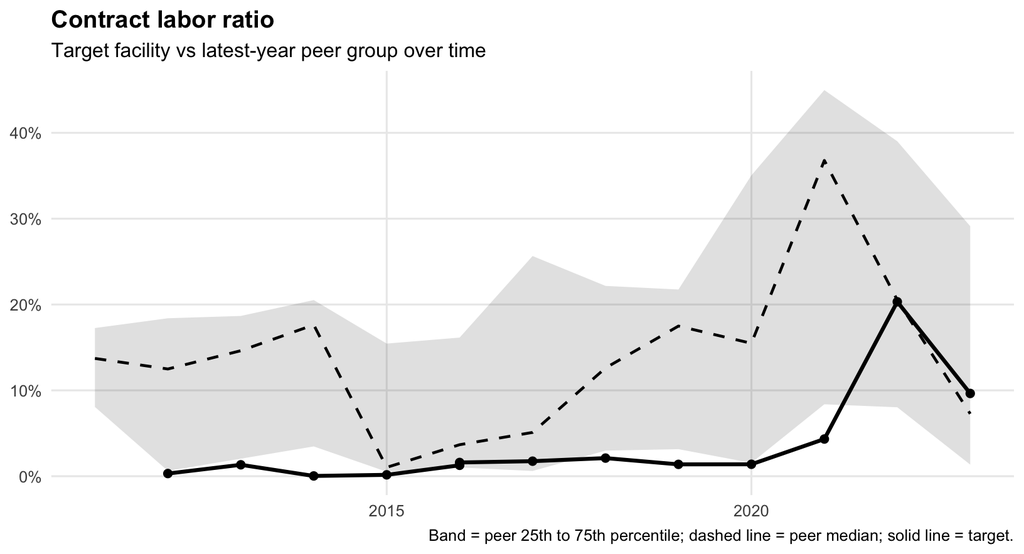

**Interpretation:** Contract labor ratio is a screening indicator for agency or contracted labor reliance. A high or rising value may suggest staffing instability, wage pressure, or temporary surge staffing, but it should be validated with PBJ staffing data.

# Consulting implications and next questions

The cost report points to financial, utilization, payer-mix, labor, and liquidity patterns. Before making operational recommendations, the next consulting step should validate these findings with additional sources:

- PBJ staffing data for RN/LPN/CNA staffing and agency reliance.
- Care Compare quality, survey, and deficiency data.
- Local hospital discharge and referral-market context.
- Medicaid rate and managed care context.
- Leadership interview or facility operating review.

**Source:** Centers for Medicare & Medicaid Services (CMS), Healthcare Cost Report Information System (HCRIS), Skilled Nursing Facility Cost Report public-use data (CMS-2540-10). This report uses cleaned Utah facility cost-report years 2011–2023 from CMS source files spanning 2010–2024. Cost-report metrics are unaudited screening indicators and should be validated with staffing, quality, survey, referral-market, rate, and management information before making operational recommendations.